# GenoPlotR: A versatile package to visualize gene context and synteny comparisons

Arturo Vera-Ponce de Leon

# GenoPlotR Basic Code:

### To perform a basic plot using this library you first need to download and install the *genoPlotR* package, you can find it at:

[link](http://genoplotr.r-forge.r-project.org/) To install:

```r
#install.packages("genoPlotR")
```

*If it is already installed you do not need to run this line*

## Once you have installed you need to import it into R like:

```r
library(genoPlotR)
```

> We are going to use other practical libraries such as:
1. **dplyr**
- To modify, parse and edit tables and data frames
2. **xlsx**
- To read tables directly from Excel worksheet

```r
library(dplyr)
library(xlsx)
```

# Inputs to Genoplot:

## *genoPlotR* needs as an input a data frame containing genes, their start and end positions as well as the DNA strand (forward +/reverse -) they are codified. The easy way to do it is by reading a General Feature Format (GFF) table like this one::

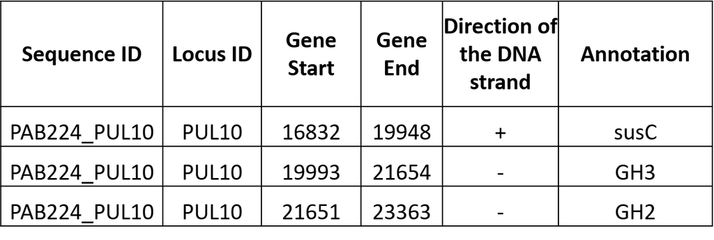

> Now let´s read a small gff from Excel ‘xlsx’ file

```r
singleGff <- read.xlsx("gff_single.xlsx",sheetIndex = 1, header = F)
singleGff
```

```
##            X1    X2           X3            X4    X5    X6 X7    X8
## 1 PAB51_PUL17 PUL17 PAB_51_02163 contig-100_18 36287 38098  - 16238
## 2 PAB51_PUL17 PUL17 PAB_51_02164 contig-100_18 38385 41486  +   287
## 3 PAB51_PUL17 PUL17 PAB_51_02165 contig-100_18 41567 43252  +    81
## 4 PAB51_PUL17 PUL17 PAB_51_02166 contig-100_18 43457 44869  +   205
## 5 PAB51_PUL17 PUL17 PAB_51_02167 contig-100_18 44920 46458  +    51
##             X9  X10
## 1 PAB_51_02163 GH32
## 2 PAB_51_02164 susC
## 3 PAB_51_02165 susD
## 4 PAB_51_02166  unk
## 5 PAB_51_02167 GH32
```

```r
class(singleGff)
```

```
## [1] "data.frame"
```

## As you see this gff file has all the elements necessary for plotting however you need to select the columns *genoPlot* needs (genome name, start, end and strand)

> let’s do a simple plot:

**First you need to name the columns in the *singleGff* data frame:**

```r
names <- c("genome",    "pulid",    "protein_id",   "contig", "start",  "end",  "strand",   "dist", "protein_name","annot")
colnames(singleGff) <- names
singleGff
```

```
##        genome pulid   protein_id        contig start   end strand  dist
## 1 PAB51_PUL17 PUL17 PAB_51_02163 contig-100_18 36287 38098      - 16238
## 2 PAB51_PUL17 PUL17 PAB_51_02164 contig-100_18 38385 41486      +   287
## 3 PAB51_PUL17 PUL17 PAB_51_02165 contig-100_18 41567 43252      +    81
## 4 PAB51_PUL17 PUL17 PAB_51_02166 contig-100_18 43457 44869      +   205
## 5 PAB51_PUL17 PUL17 PAB_51_02167 contig-100_18 44920 46458      +    51
##   protein_name annot
## 1 PAB_51_02163  GH32
## 2 PAB_51_02164  susC
## 3 PAB_51_02165  susD
## 4 PAB_51_02166   unk
## 5 PAB_51_02167  GH32
```

**Now we can taking advantage of R data frames and select the useful columns by typing their names to generate a new dataframe just like genoPlot ask for**

```r
singleDF <- data.frame(name=singleGff$annot,
                   start= singleGff$start,
                   end=singleGff$end,
                   strand=singleGff$strand)
singleDF
```

```
##   name start   end strand
## 1 GH32 36287 38098      -
## 2 susC 38385 41486      +
## 3 susD 41567 43252      +
## 4  unk 43457 44869      +
## 5 GH32 44920 46458      +
```

**Next, we can use this *singleDF* data frame to create a *dna_seg* object** *(dna_seg is a function from genoPlotR)*

```r
dna_seg <- dna_seg(singleDF)
class(dna_seg)
```

```
## [1] "dna_seg"    "data.frame"
```

```r
dna_seg
```

```
##   name start   end strand  col fill lty lwd pch cex gene_type
## 1 GH32 36287 38098     -1 blue blue   1   1   8   1    arrows
## 2 susC 38385 41486      1 blue blue   1   1   8   1    arrows
## 3 susD 41567 43252      1 blue blue   1   1   8   1    arrows
## 4  unk 43457 44869      1 blue blue   1   1   8   1    arrows
## 5 GH32 44920 46458      1 blue blue   1   1   8   1    arrows
```

> This is the minimal information you need for plotting so let’s print it using the *plot_gene_map* function from *genoPlot*

**As genoplot works with list type objects you first must transform the dna_seg object into a list**

```r
dna_segs <- list(dna_seg)
```

Then you can call up the *plot_gene_map* function

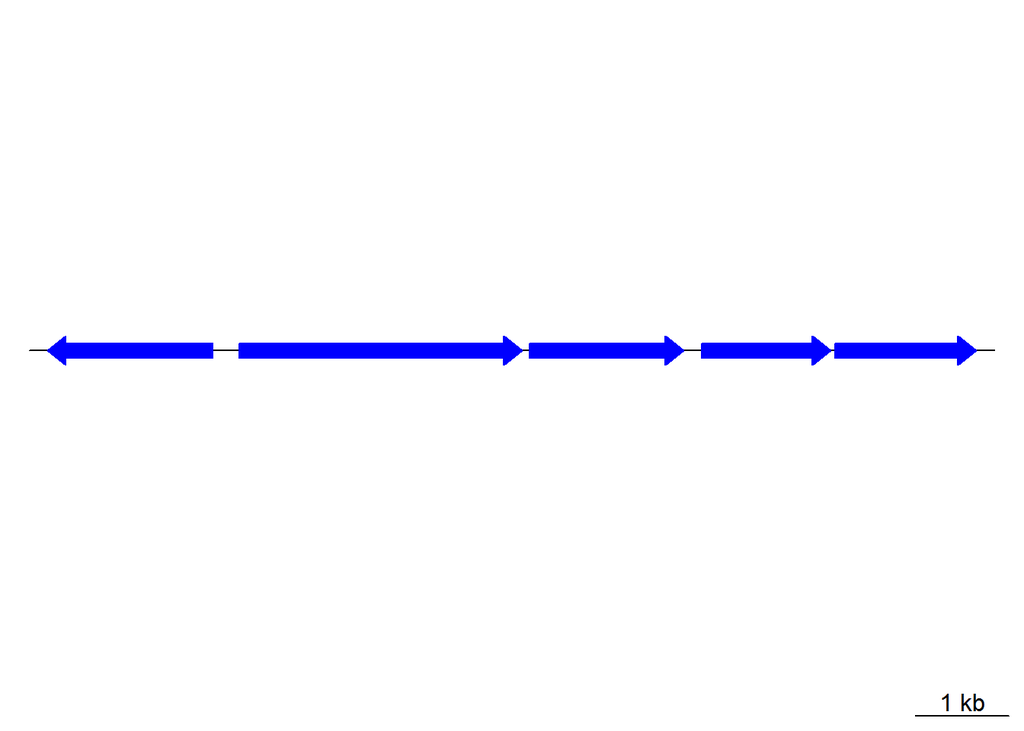

```r
plot_gene_map(dna_segs = dna_segs)
```

**Additionally, genoPlot is able to add annotations to the genes.**

- For doing this we need to parse the *name* column (which has the annotations) from the *dna_seg* object by using the *annotation* function from *genoPlot*. You can also use this function to indicate the direction of the text (*rot* for the rotation angle) and the possition in the arrow (gene) representation (*middle* if you like it in the center of the arrow)

```r
annot <- annotation(x1=middle(dna_seg),
                    text=dna_seg$name, rot=18)
class(annot)
```

```
## [1] "annotation" "data.frame"
```

```r
annot
```

```
##        x1 x2 text color rot
## 1 37192.5 NA GH32 black  18
## 2 39935.5 NA susC black  18
## 3 42409.5 NA susD black  18
## 4 44163.0 NA  unk black  18
## 5 45689.0 NA GH32 black  18
```

> **With these objects (*dna_segs* and *annotations*) now we can create a plot with all the genes and their annotation using *plot_gene_map* function:**

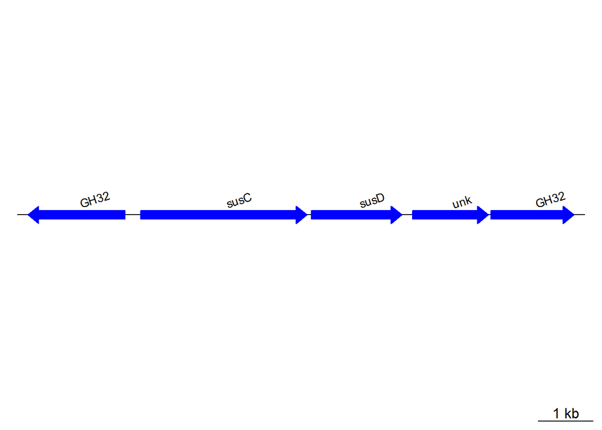

```r
dna_segs <- list(dna_seg)
plot_gene_map(dna_segs=dna_segs,annotations = annot)
```

> As you can see now we have created a plot with arrows (genes) and names (annotations), but it is difficult to differentiate among all the genes and annotations

**So lets add a color code for each different gene**

To do this, we need to add a new column to the *singleDF* data frame using a color code we like, In this example we will use an *ifelse* loop to add a color depending to the annotation from the *singleDF* object we are using *grepl* function to look and extract the genes we want

We want to display:

1. All GH genes in green
2. All susC genes in purple
3. All susD genes in orange
4. Any other gene in gray

**Now Using this new datafame we just need to modify the first *singleDF* data frame adding the color colum like this:**

```r
singleDF$col <- ifelse(grepl("GH", singleGff$annot),"yellowgreen",
                          ifelse(grepl("susC",singleGff$annot), "purple",
                                 ifelse(grepl("susD",singleGff$annot),"orange",
                                        "gray")))
singleDF
```

```
##   name start   end strand         col
## 1 GH32 36287 38098      - yellowgreen
## 2 susC 38385 41486      +      purple
## 3 susD 41567 43252      +      orange
## 4  unk 43457 44869      +        gray
## 5 GH32 44920 46458      + yellowgreen
```

**We can modify a little bit the previous code to produce new plots but now filling the arrows (genes) with the colors we chose**

- Filling the arrows can be done by adding the *fill* flag to the *dna_seg* and specify to use the new column color

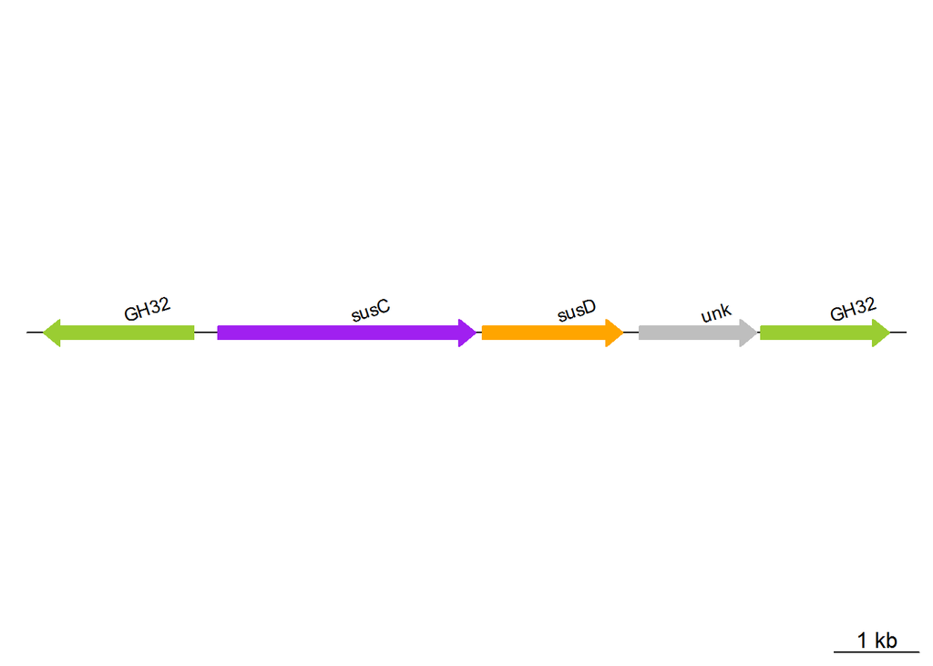

```r
dna_segColor <- dna_seg(singleDF,fill=singleDF$col)
annotColor <- annotation(x1=middle(dna_segColor),
                    text=dna_segColor$name, rot=18)
dnasegsColor<- list(dna_segColor)
plot_gene_map(dna_segs=dnasegsColor,annotations = annotColor)
```

# We already have the basic plot but GenoplotR is useful to analyze syntenic comparisons as well.

- Now we can compare two different loci from two different genomes.

**Reading an excel gff table with two loci**

```r
multipleGff <- read.xlsx("gff_two.xlsx",sheetIndex = 1, header=F)
Names <- c("genome",    "pulid",    "protein_id",   "contig", "start",  "end",  "strand",   "dist", "protein_name","annot")
colnames(multipleGff) <- Names
```

As genoplot uses a list of dna_segs for plotting we need to generate one *dna_seg* for each locus. For doing this, we can split the *multipleGff* dataframe using a for loop and then save them into a list object *list.data*

```r
list.data<-list()
for (i in 1:length(levels(multipleGff$genome))){
  a<-levels(multipleGff$genome)[[i]]
  list.data[[i]] <- dplyr::filter(multipleGff,multipleGff$genome==a)
}
```

As we want that each gene will be displayed in different colors we can generate a color column directly within this list. We can create a function and then apply to all elemnts to the list using the *lapply* function like this:

```r
color  <- function(x) {
  x$color <- ifelse(grepl("GH", x$annot),"yellowgreen",
                    ifelse(grepl("susC",x$annot), "purple",
                           ifelse(grepl("susD",x$annot),"orange",
                                  "gray")))
  return(x)
}
list.data <- lapply(list.data,color)
```

Then we can name each dataframe with the genome name of each locus using the *genome* column from the multipleGff dataframe like:

```r
LEVELS <- as.vector(levels(multipleGff$genome))
names(list.data) <- LEVELS
```

**Now we have the list we can use lapply function again to generate a list of *dna_seg* objects and their *annotations* one per each loci in each genome**

```r
#Obtaining dna_segments
DF <- function(x){
  DF.x <- data.frame(name=x$annot,
                     start= x$start,
                     end=x$end,
                     strand=x$strand,
                     col=x$color)
}

for.segments <- lapply(list.data,DF)
segment <- function(x){
  dna_seg.x <- dna_seg(x,fill =x$col)
}

dna_segsMultiple <- lapply(for.segments,segment)

#Obtainig annotation
annota <- function(x){
  mid <- middle(x)
  annot <- annotation(x1=mid, text=x$name, rot=18)
}
annotsMultiple <- lapply(dna_segsMultiple,annota)
```

> Here we can plot and see if our code has worked or not

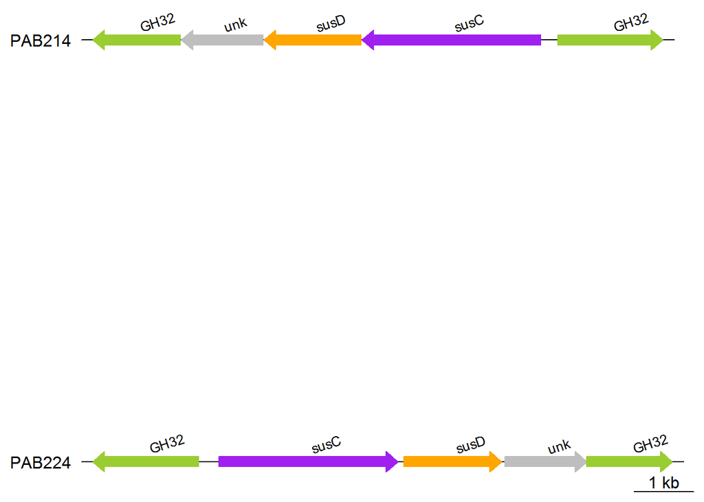

```r
plot_gene_map(dna_segs=dna_segsMultiple,annotations = annotsMultiple)
```

**Now we need to create the second main object used by genoplot a *comparison dataframe*. We basically need to tell genoplot the position of the homologous genes in each locus. For this we can use the start and end columns in the dataframes**

```r
comparison1 <- comparison(data.frame(start1=sort(dna_segsMultiple$PAB214$end,decreasing = TRUE),
                                     end1=sort(dna_segsMultiple$PAB214$start,decreasing=TRUE),
                                     start2=dna_segsMultiple$PAB224$start,
                                     end2=dna_segsMultiple$PAB224$end,
                                     col="#BFBFBF80"))
```

*remember if the genes are in the reverse chain you need to specify first the end and then the start inverting the orden by using the decreasing function*

**As genoplot likes to use list we need to save the comparison into a list**

```r
comparisons <- list(comparison1)
```

> Now we can plot our syntenic genes using again the *plot_gene_map* fucntion

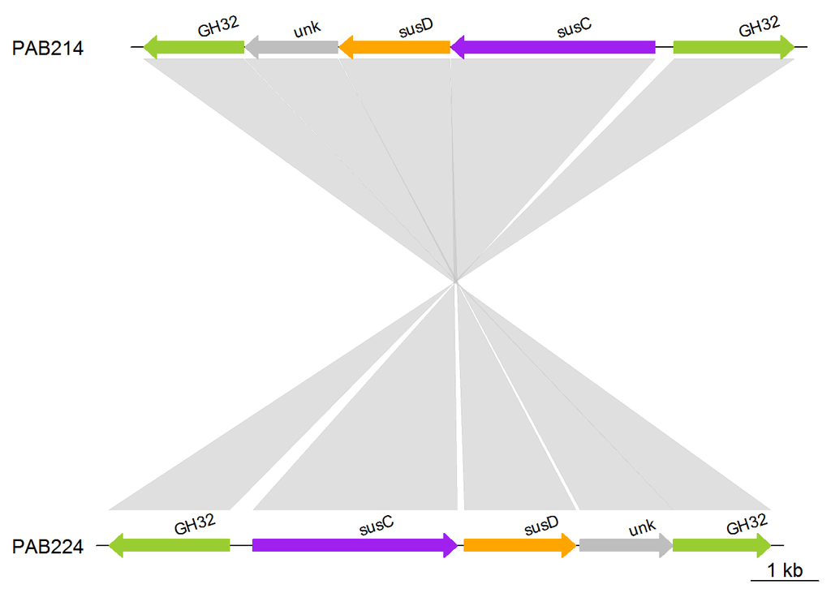

```r
plot_gene_map(dna_segs=dna_segsMultiple,annotations = annotsMultiple, comparisons = comparisons)
```